# R plots by Pawel Mrozowski

# Overview

```
##      X1965     X1966          X1967          X1968          X1969
##  Min.   :0    Mode:logical   Mode:logical   Mode:logical   Mode:logical
##  1st Qu.:0    NA's:275       NA's:275       NA's:275       NA's:275
##  Median :0
##  Mean   :0
##  3rd Qu.:0
##  Max.   :0
##  NA's   :79
##      X1970     X1971          X1972          X1973          X1974
##  Min.   :0    Mode:logical   Mode:logical   Mode:logical   Mode:logical
##  1st Qu.:0    NA's:275       NA's:275       NA's:275       NA's:275
##  Median :0
##  Mean   :0
##  3rd Qu.:0
##  Max.   :0
##  NA's   :79
##      X1975        X1976        X1977        X1978        X1979
##  Min.   :0    Min.   :0    Min.   :0    Min.   :0    Min.   :0
##  1st Qu.:0    1st Qu.:0    1st Qu.:0    1st Qu.:0    1st Qu.:0
##  Median :0    Median :0    Median :0    Median :0    Median :0
##  Mean   :0    Mean   :0    Mean   :0    Mean   :0    Mean   :0
##  3rd Qu.:0    3rd Qu.:0    3rd Qu.:0    3rd Qu.:0    3rd Qu.:0
##  Max.   :0    Max.   :0    Max.   :0    Max.   :0    Max.   :0
##  NA's   :79   NA's   :79   NA's   :79   NA's   :79   NA's   :79
##      X1980             X1981             X1982             X1983
##  Min.   :    0.0   Min.   :    0.0   Min.   :    0.0   Min.   :    0.0
##  1st Qu.:    0.0   1st Qu.:    0.0   1st Qu.:    0.0   1st Qu.:    0.0
##  Median :    0.0   Median :    0.0   Median :    0.0   Median :    0.0
##  Mean   :  119.8   Mean   :  326.1   Mean   :  520.6   Mean   :  767.3
##  3rd Qu.:    0.0   3rd Qu.:    0.0   3rd Qu.:    0.0   3rd Qu.:    0.0
##  Max.   :23482.0   Max.   :28278.0   Max.   :33880.0   Max.   :42226.0
##  NA's   :79        NA's   :80        NA's   :80        NA's   :81
##      X1984           X1985            X1986            X1987
##  Min.   :    0   Min.   :     0   Min.   :     0   Min.   :      0
##  1st Qu.:    0   1st Qu.:     0   1st Qu.:     0   1st Qu.:      0
##  Median :    0   Median :     0   Median :     0   Median :      0
##  Mean   : 1663   Mean   :  3930   Mean   :  7514   Mean   :  13326
##  3rd Qu.:    0   3rd Qu.:     0   3rd Qu.:     0   3rd Qu.:      0
##  Max.   :91600   Max.   :340213   Max.   :681825   Max.   :1230855
##  NA's   :83      NA's   :84       NA's   :82       NA's   :84
```

[output cut: 49 more lines]

```
##  Min.   :        0   Min.   :        0   Min.   :     1000
##  1st Qu.:   380418   1st Qu.:   600000   1st Qu.:   668237
##  Median :  2501140   Median :  3394016   Median :  4081632
##  Mean   : 16558541   Mean   : 19928682   Mean   : 22870061
##  3rd Qu.:  9932983   3rd Qu.: 11684479   3rd Qu.: 13227396
##  Max.   :547306000   Max.   :641245000   Max.   :747214000
##  NA's   :73          NA's   :74          NA's   :73
##      X2010               X2011
##  Min.   :     1600   Min.   :     2130
##  1st Qu.:   956924   1st Qu.:  1324654
##  Median :  4909666   Median :  6426526
##  Mean   : 26403896   Mean   : 31216042
##  3rd Qu.: 14040479   3rd Qu.: 18129152
##  Max.   :859003000   Max.   :986253000
##  NA's   :75          NA's   :85
```

```
##                       X1965 X1966 X1967 X1968 X1969 X1970 X1971 X1972
## Abkhazia                 NA    NA    NA    NA    NA    NA    NA    NA
## Afghanistan               0    NA    NA    NA    NA     0    NA    NA
## Akrotiri and Dhekelia    NA    NA    NA    NA    NA    NA    NA    NA
## Albania                   0    NA    NA    NA    NA     0    NA    NA
## Algeria                   0    NA    NA    NA    NA     0    NA    NA
## American Samoa            0    NA    NA    NA    NA     0    NA    NA
##                       X1973 X1974 X1975 X1976 X1977 X1978 X1979 X1980
## Abkhazia                 NA    NA    NA    NA    NA    NA    NA    NA
## Afghanistan              NA    NA     0     0     0     0     0     0
## Akrotiri and Dhekelia    NA    NA    NA    NA    NA    NA    NA    NA
## Albania                  NA    NA     0     0     0     0     0     0
## Algeria                  NA    NA     0     0     0     0     0     0
## American Samoa           NA    NA     0     0     0     0     0     0
##                       X1981 X1982 X1983 X1984 X1985 X1986 X1987 X1988
## Abkhazia                 NA    NA    NA    NA    NA    NA    NA    NA
## Afghanistan               0     0     0     0     0     0     0     0
## Akrotiri and Dhekelia    NA    NA    NA    NA    NA    NA    NA    NA
## Albania                   0     0     0     0     0     0     0     0
## Algeria                   0     0     0     0     0     0     0     0
## American Samoa            0     0     0     0     0     0    NA    NA
##                       X1989 X1990 X1991 X1992 X1993 X1994 X1995 X1996
## Abkhazia                 NA    NA    NA    NA    NA    NA    NA    NA
## Afghanistan               0     0     0     0     0     0     0     0
## Akrotiri and Dhekelia    NA    NA    NA    NA    NA    NA    NA    NA
## Albania                   0     0     0     0     0     0     0  2300
## Algeria                   0   470  4781  4781  4781  1348  4691 11700
## American Samoa           NA     0     0   700   900  1200  1250  1300
##                       X1997 X1998 X1999 X2000  X2001  X2002   X2003
## Abkhazia                 NA    NA    NA    NA     NA     NA      NA
## Afghanistan               0     0     0     0      0  25000  200000
## Akrotiri and Dhekelia    NA    NA    NA    NA     NA     NA      NA
## Albania                3300  5600 11008 29791 392650 851000 1100000
## Algeria               17400 18000 72000 86000 100000 450244 1446927
## American Samoa         1400  1500  1800  1992   2156   2036    2100
##                         X2004    X2005    X2006    X2007    X2008    X2009
## Abkhazia                   NA       NA       NA       NA       NA       NA
## Afghanistan            600000  1200000  2520366  4668096  7898909 10500000
## Akrotiri and Dhekelia      NA       NA       NA       NA       NA       NA
## Albania               1259590  1530244  1909885  2322436  1859632  2463741
## Algeria               4882414 13661355 20997954 27562721 27031472 32729824
## American Samoa           2250       NA       NA       NA       NA       NA
##                          X2010    X2011
## Abkhazia                    NA       NA
## Afghanistan           13000000 17558265
## Akrotiri and Dhekelia       NA       NA
## Albania                2692372  3100000
## Algeria               32780165 35615926
## American Samoa              NA       NA
```

# Univariate Analysis

Firstly we try to take a look on quantity of phones in all dataset

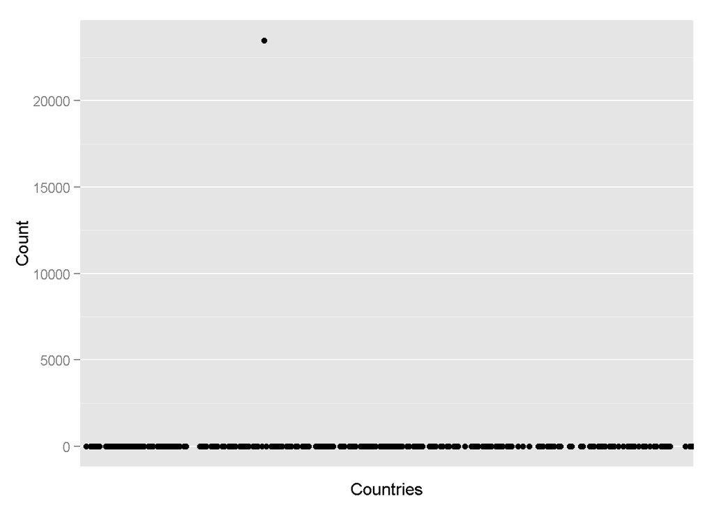

There is one interesting point, we try to find what is this country by taking top data from dataframe for this year

We must find the name of country with max value and value itself:

First we check which row has maximum value

```
## [1] 76
```

the value is

```
## [1] 23482
```

and what is the conutry

```
## [1] Finland
## 275 Levels: Ă…land Abkhazia Afghanistan Akrotiri and Dhekelia ... Zimbabwe
```

So we have confirmation that in fact the only country in the dataset that had cell phones was Finland.

We move to year 2010 and do some visualization. Having value points for year 2010 we want to show average value for this year on the plot . First we calculate average value for year 2010.

```
##    X2010
## 26403896
```

Now we add this as layer to plot.

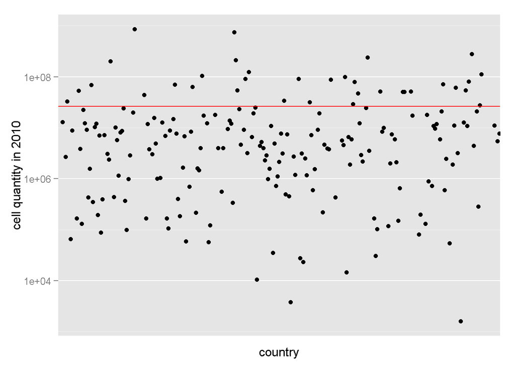

Now last thing we want to know is how many countries have quantity above average.

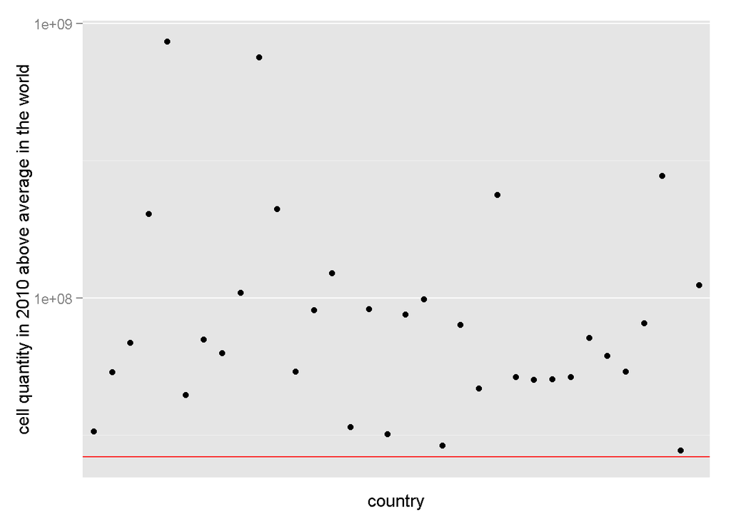

```
##     Mobile.cellular.subscriptions..total.number
## 5                                       Algeria
## 11                                    Argentina
## 19                                   Bangladesh
## 30                                       Brazil
## 45                                        China
## 48                                     Colombia
## 66                                        Egypt
## 77                                       France
## 83                                      Germany
## 102                                       India
## 103                                   Indonesia
## 104                                        Iran
## 109                                       Italy
## 111                                       Japan
```

[output cut: 20 more lines]

# Bivariate Analysis

Here we begin bivariate analysis. The structure of dataset is simple. From one side we have Countries, from the other we have rows/columns with cell phone quantities since 1965 till 2011 as separated values. So actually to begin analysis we must create some new variables like average/total amount by binding some data.We are going to compare overall data set characteristics with my country Poland.

We want to answer a few questions: 1- how the total amount of phones changed over time 2- how the total amount of phones changed in Poland and compare it with global analysis 3- how is the relation between world trend to my country’s trend

Since the data is in separated columns we must build two variables: years and total

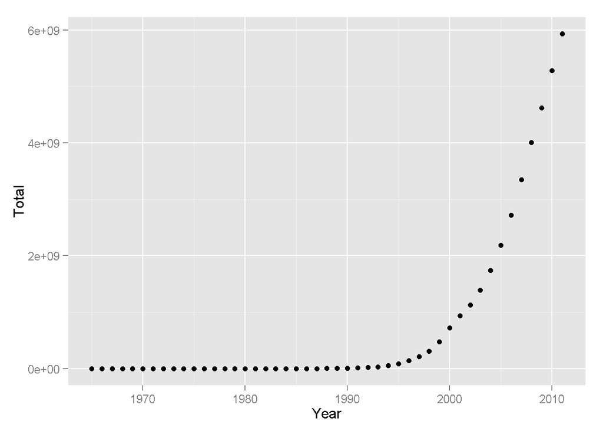

Now we can narrow this growth to one country, e.g. Poland and compare this with total value for all dataset.

```
##    Poland
## 370378624
```

Now let’s visualize cell quantity in Poland.

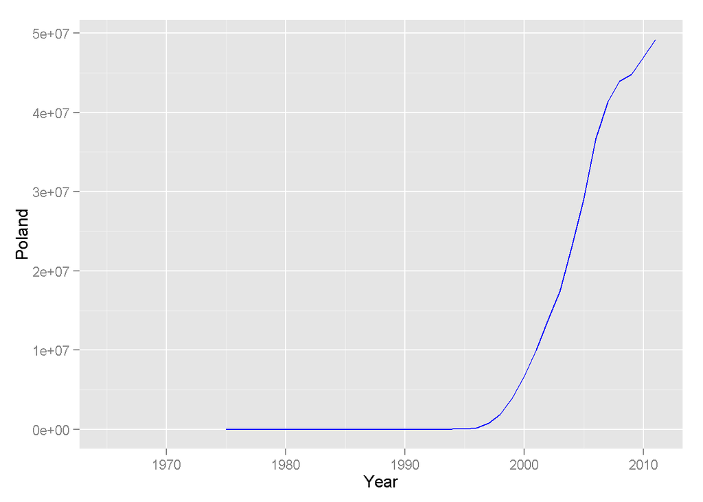

We can see that significant increase occured in 1995 till 2005.

Now let’s change scale to see it better.

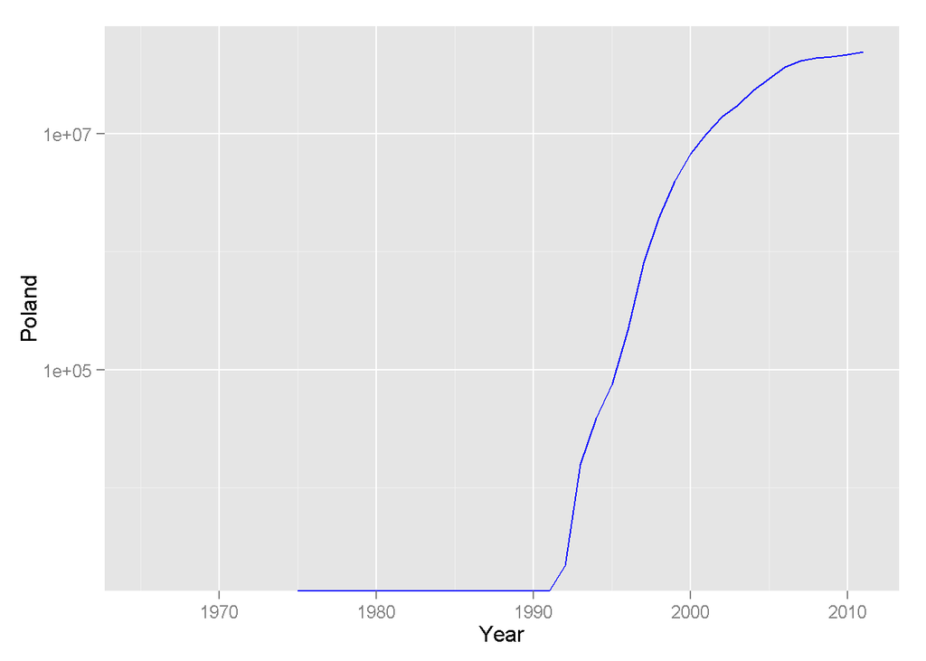

We can now compare both values and avarage in the world: plots on one graph to see how Poland is related to overall total number

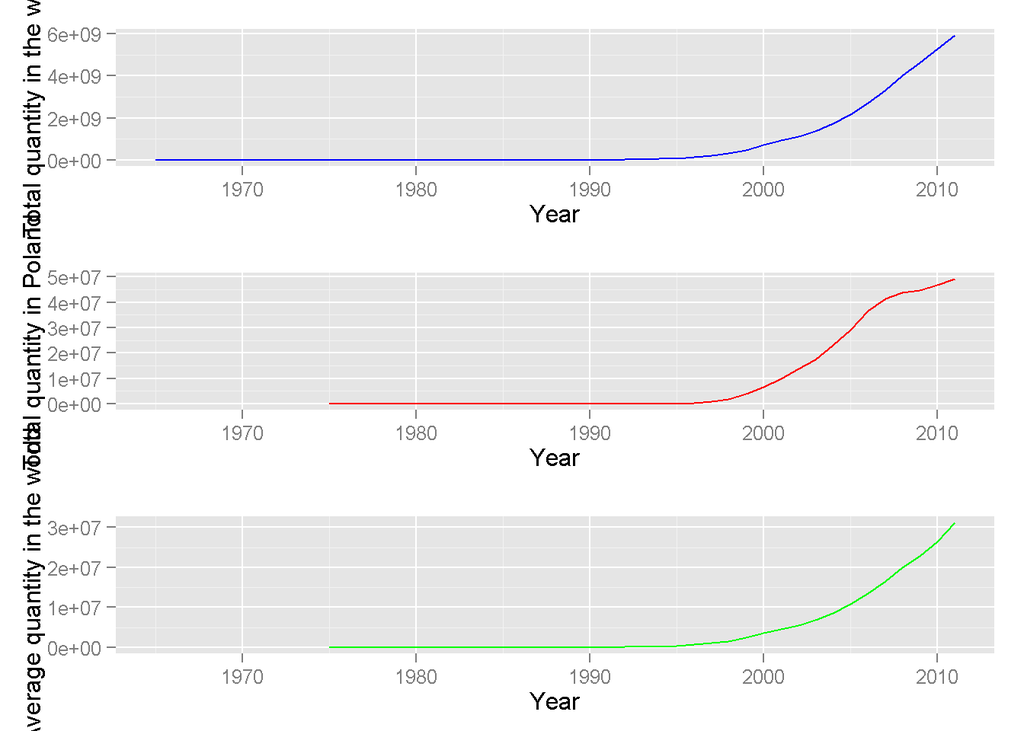

We can see that the shape is different and the increase of phones tends to slow down from 2008 and 2009 . Now let’s change Y scale in the same way we did before.

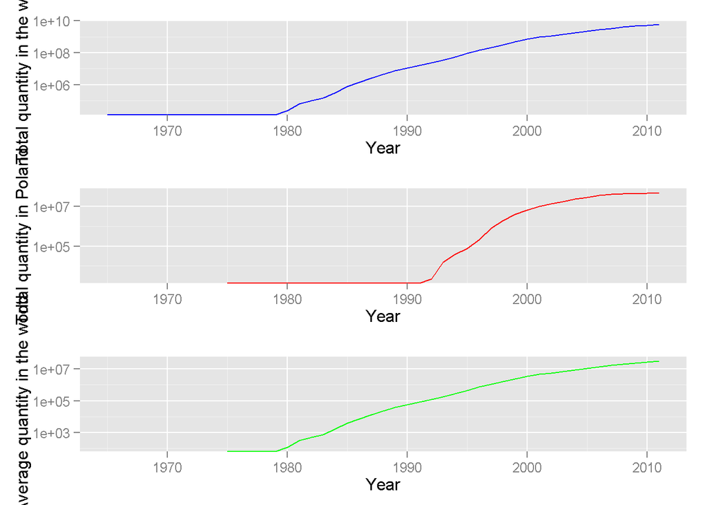

We can see that the shape of function is similar but is relatively x times less (obvious) but also started about 10 years after world’s trend, which is justified taking into account the political aspect of Poland. Year 1989 is actually the fists year of capitalism and end of communism, so country coud benefit from hith tech that was forbidden before.

# Final Plots and Summary

### Plot One

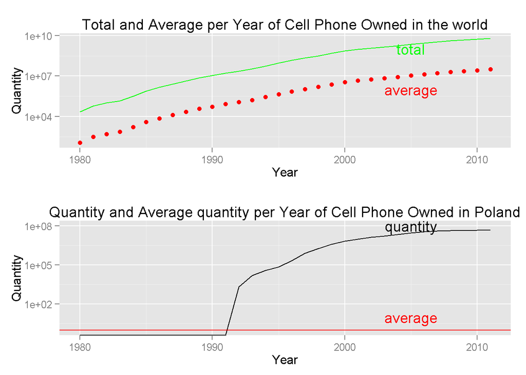

### Description One

First plot’s task is to show relation of Average and Total amount of cell phones in the world related to Poland : quantity,average and total amount

### Plot Two

```
##    Min. 1st Qu.  Median    Mean 3rd Qu.    Max.    NA's
##  0.6975  1.0340  1.0760  1.1260  1.1660  2.3150      86
```

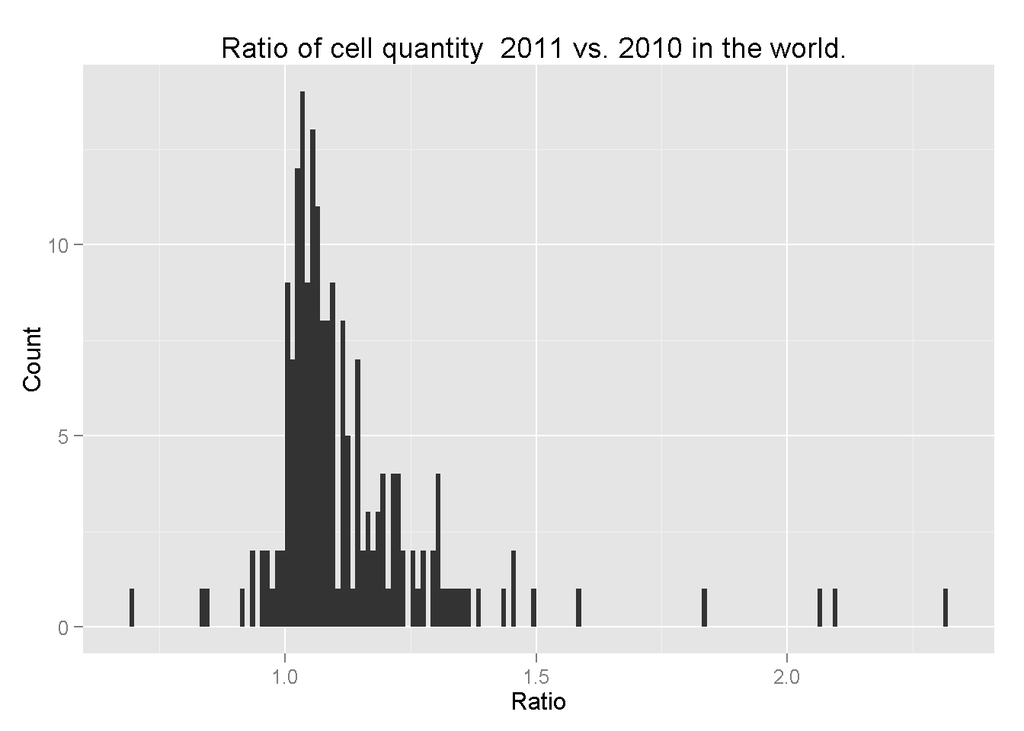

### Plot Three

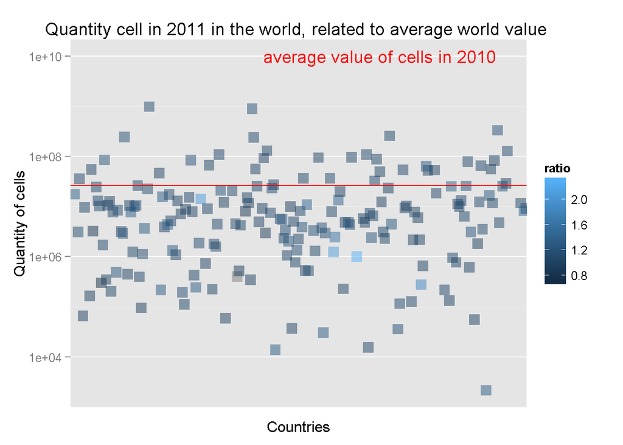

### Description Three

Next plot shows relation of cell quantity or all datates in 2011 to an average value on logarithmic scale. More, we coloured values in respect to ratio of growth between 2011 and 2010. We can see that actually the countries with highest ratio are below average value. This can indicate some growing markets, not necessary the big ones like USA, Germany, UK.

# Reflection

By anlysing the data we can see the very beginning of cellular telephony in 80’ growing steadily with a boom in late 90’ and in the next decade. Poland was 10 years behind world’s trend until 1989 . Today Poland is actually the leader of LTE technology in Europe by having the most users and signal coverage. First difficulty I had was related to the data itself. I had to create csv file with header and import it properly to R. Structure shows that this is actually a spreadsheet of values that had to be analysed, combined, summed etc. in order to begin finding patterns.

# Resources

R CookBook

http://www.cookbook-r.com

http://www.ademcan.net